# H.11.2

#### Dependencies

```r
library(tidyverse)
library(ggfortify)
```

#### Data Import

```r
bolts <- read_csv(file = "rusty_bolt.csv")
slice(bolts)
```

```
## # A tibble: 28 x 2
##    treatment   torque
##    <chr>        <dbl>
##  1 none          110.
##  2 none          123.
##  3 none          141.
##  4 none          129.
##  5 Acetone/ATF   114.
##  6 Acetone/ATF   130.
##  7 Acetone/ATF   106.
##  8 Acetone/ATF   107.
##  9 AeroKroil     134.
## 10 AeroKroil     125.
## # ... with 18 more rows
```

#### a) **Answer:**

It is reasonable to apply ANOVA in order to compare the means of more than 2 groups, in our case 7. However, in order to apply ANOVA, 3 conditions must match - In our case it is difficult to proof for any of the conditions due to a limit amount of information. For this reason, we will apply ANOVA but we should be very critical towards the results outputed.

1. **Independence within and between groups:** in our case it is difficult to check this requirement because we do not know if the sample is randomized;
2. **Nearly Normal:** The samples for each category is really small (4 respectively). So we assume normaly but in theory a lot of skewness take place.
3. **Variability across groups should be equal:** Due to the small number of observations per group is difficult to say anything about the variability.

```r
bolts %>%
  group_by(treatment) %>%
  summarise(n=n(), mean=mean(torque), sd =sd(torque))
```

```
## # A tibble: 7 x 4
##   treatment         n  mean    sd
##   <chr>         <int> <dbl> <dbl>
## 1 Acetone/ATF       4 114.  11.0
## 2 AeroKroil         4 125.  12.3
## 3 Liquid Wrench     4  97.3 12.5
## 4 none              4 126.  12.8
## 5 PB Blaster        4 122.   7.90
## 6 Royal Purple      4 119.  10.1
## 7 WD-40             4 121.  11.9
```

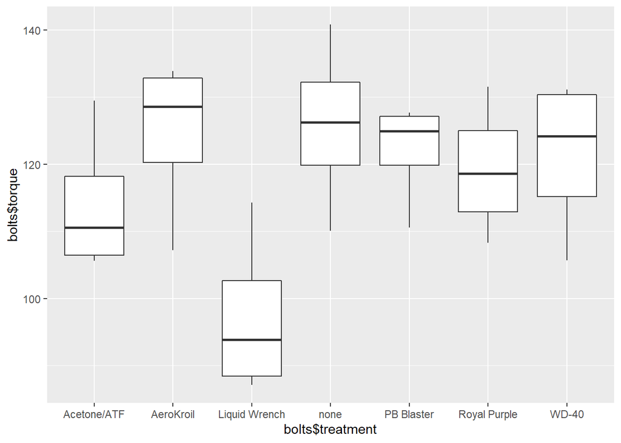

```r
ggplot(bolts, aes(bolts$treatment, bolts$torque)) + geom_boxplot()
```

#### b) ANOVA

**Null Hypothesis** $N_{0}:$ The mean outcome is the same across all categories, or only differ by chance.  
**Alternative Hypothesis** $N_{A}:$ At least one mean outcome is different than other.

```r
mod_bolts <- aov(torque ~ treatment, data = bolts)
summary(mod_bolts)
```

```
##             Df Sum Sq Mean Sq F value Pr(>F)
## treatment    6   2312   385.3   3.005  0.028 *
## Residuals   21   2693   128.2
## ---
## Signif. codes:  0 '***' 0.001 '**' 0.01 '*' 0.05 '.' 0.1 ' ' 1
```

**Answer:** We can reject the the $N_{0}$ because the p-value is very small. Based on the outputs from the ANOVA test it is reasonable to say that at least one mean of a group is different compared to the rest. However, we can’t say which group is the different one, and for this reason one can conclude that there is at least one theatment which is more or less effective than the other when it comes to treating rusty bolts.

#### c) Boxplot of torque

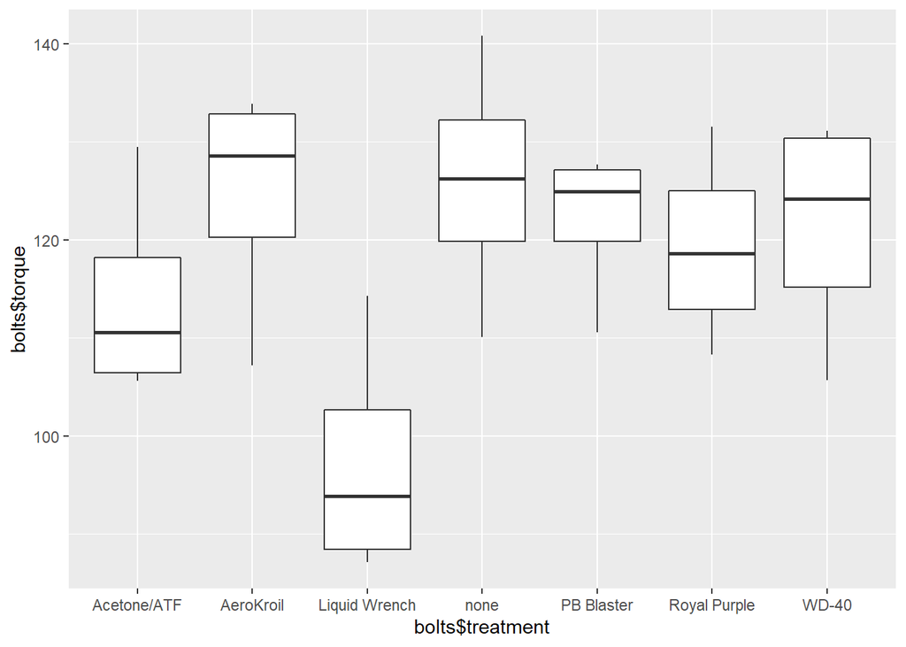

```r
ggplot(bolts, aes(bolts$treatment, bolts$torque)) + geom_boxplot()
```

#### d) Tukey’s honestly significant difference test

```r
TukeyHSD(mod_bolts)
```

```
##   Tukey multiple comparisons of means
##     95% family-wise confidence level
##
## Fit: aov(formula = torque ~ treatment, data = bolts)
##
## $treatment
##                               diff        lwr       upr     p adj
## AeroKroil-Acetone/ATF       10.500 -15.528871 36.528871 0.8392155
## Liquid Wrench-Acetone/ATF  -16.775 -42.803871  9.253871 0.3905832
## none-Acetone/ATF            11.800 -14.228871 37.828871 0.7564533
## PB Blaster-Acetone/ATF       7.975 -18.053871 34.003871 0.9493275
## Royal Purple-Acetone/ATF     5.200 -20.828871 31.228871 0.9940450
## WD-40-Acetone/ATF            7.250 -18.778871 33.278871 0.9675997
## Liquid Wrench-AeroKroil    -27.275 -53.303871 -1.246129 0.0360682
## none-AeroKroil               1.300 -24.728871 27.328871 0.9999980
## PB Blaster-AeroKroil        -2.525 -28.553871 23.503871 0.9998992
## Royal Purple-AeroKroil      -5.300 -31.328871 20.728871 0.9934082
## WD-40-AeroKroil             -3.250 -29.278871 22.778871 0.9995651
## none-Liquid Wrench          28.575   2.546129 54.603871 0.0254618
## PB Blaster-Liquid Wrench    24.750  -1.278871 50.778871 0.0693050
## Royal Purple-Liquid Wrench  21.975  -4.053871 48.003871 0.1355122
## WD-40-Liquid Wrench         24.025  -2.003871 50.053871 0.0830228
## PB Blaster-none             -3.825 -29.853871 22.203871 0.9989015
## Royal Purple-none           -6.600 -32.628871 19.428871 0.9795396
## WD-40-none                  -4.550 -30.578871 21.478871 0.9971128
## Royal Purple-PB Blaster     -2.775 -28.803871 23.253871 0.9998253
## WD-40-PB Blaster            -0.725 -26.753871 25.303871 0.9999999
## WD-40-Royal Purple           2.050 -23.978871 28.078871 0.9999703
```